# 2.06-Stacks-Queues

### Topics Covered

- Stacks - Introduction
- Stacks - Array Implementation
- Stacks - Linked Lists Implementation
- Queues - Introduction
- Queues - Linked Lists Implementation
- Queues - Deques

### Introduction to Stacks

So up until now, when we discuss data structures, we always thought about them in terms of different ways of storing data. Regular arrays are stored with indices and linked lists with nodes. Stacks and queues are different in that regard

**Linear data structure** : A data structure is defined as linear when it has its elements arranged in a sequence one after another, all on the same level.

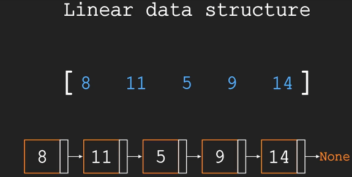

This means that a linear data structure has two possible extremities, two ends. Examples of such data structures are arrays, singly linked lists, and doubly linked lists. So all of those which we learned until now can be described as being linear. They're all arranged in a sequential manner

**Stacks** :

A stack can be any one of these linear data structures, as long as it follows one rule, and that is to allow adding and removing elements from only one of its ends

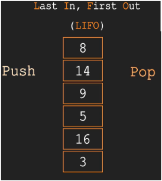

Oftentimes, stacks are visualized vertically, with the entry and exit point being the top. The actions of adding and removing elements are called `Push` and `Pop`.

We push new elements onto the stack. And then we pop them off the stack. You can imagine this action as if you were looking down from above the stack, and you can only see and access the top element. Some people like to compare Stacks with the real life example of a stack of trays in the cafeteria. When we want to add more trays, we put them on top of the existing ones, and when we take a tray, we take the top one.

But whether you like to imagine a stack vertically or horizontally, the only rule you need to remember is that **Stacks only use one end for accessing elements**. And regardless of whether you use regular arrays, singly linked lists, or doubly linked lists, as long as you follow this rule, you have a stack

### Stacks - Array Implementation

A stack operates like a pile of plates (LIFO - Last-In, First-Out)—the last one placed on top is the first one removed. In programming, this means that the most recently added element is the one accessed first. You use push (to add) and pop (to remove) operations.

**Array-Based Stack Implementation**

In Python, stacks can be implemented using lists since lists provide dynamic resizing and support stack operations efficiently.

- Operations in an Array-Based Stack
  1. Push – Adds an item to the top of the stack.
  2. Pop – Removes and returns the top item.
  3. Peek – Views the top item without removing it.
  4. isEmpty – Checks if the stack is empty.

**Python Implementation Using Lists**

```python
class stack:
    def __init__(self): # - Initializes an empty list to represent the stack.
        self.stack = [] # Best practice: Consider prefixing with  if you want to emphasize privacy (though Python doesn’t enforce it).

    def push(self,item): # Adds an item to the top of the stack.
        self.stack.append(item)

    def pop(self): # Removes and returns the top item
        if not self.is_empty():
            return self.stack.pop()
        else : # - Improvement: Instead of raising a generic Exception, raise a more specific one like IndexError or create a custom StackEmptyError.
            raise Exception ("Stack is empty")

    def peek(self): # Returns the top item without removing it.
        return self.stack[-1] if not self.is_empty() else None  # single-line conditional return whch is equivalent to code below in comments

    def is_empty(self): # Checks if the stack is empty.
        return len(self.stack) == 0


#  if not self.is_empty():
#      return self.stack[-1]
#  else:
#      return None
```

```python
# Creating an object using the class name
pp=stack()
```

```python
pp.push(20)
```

```python
pp.push(10)
```

```python
print(pp.pop())
# Following the LIFO order
```

```
10
```

When you write self.stack = [], That means self.stack is a Python list object.

- Python lists already have methods defined in the language itself:
  - list.append(item) → adds an element to the end.
  - list.pop() → removes and returns the last element.
  - list[-1] → retrieves the last element without removing it.

So when you call: **self.stack.append(item)** you’re not calling your own method — you’re calling the **list’s built-in method**.

- You’re wrapping Python’s list inside your Stack class.
- This is called composition: your class uses another object (a list) internally to provide functionality.
- Instead of reinventing the wheel, you leverage Python’s list methods to implement stack behavior.

**Analogy**

Think of it like this:- You bought a toolbox (list) that already has a hammer (append) and screwdriver (pop).

- You build a new box (Stack) that contains the toolbox.
- When you need to hammer a nail, you don’t reinvent a hammer — you just reach into the toolbox and use the existing one.

Lets look at the diagram below showing how your Stack class wraps around Python’s list, and how method calls like push → append flow internally.

Your Stack class is essentially a wrapper around Python’s list. Instead of reinventing the wheel, you reuse the list’s built‑in methods to implement stack behavior. This is why you didn’t need to define `append` or `pop` yourself — they already exist inside the list object.

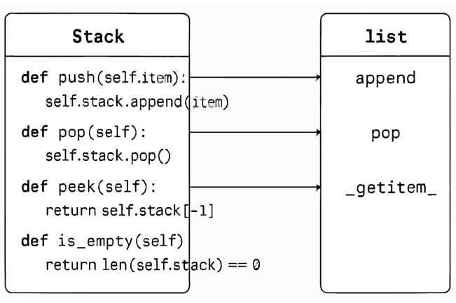

**Advantages of Array-Based Stacks**

- Simple & Built-In Support – Uses Python's dynamic lists.
- Fast Operations – O(1) time complexity for push() and pop().
- Efficient Memory Use – No extra pointer storage like in linked lists.

A stack operates like a pile of plates (LIFO - Last-In, First-Out)—the last one placed on top is the first one removed. In programming, this means that the most recently added element is the one accessed first. You use push (to add) and pop (to remove) operations.

```python
# Creating a new Empty Python list
stack1 = []
```

```python
# Lets add new elements to the stack and notice the order in which they are saved
stack1.append(3) # First Entry
stack1.append(30) # 2nd Entry
print(stack1) # to view how entries are made
```

```
[3, 30]
```

```python
# Now we will use the Python function "Pop" to extract the last/latest value from the list
stack1.pop()
```

```
30
```

```python
# We will Pop again to extract the 1st entry
stack1.pop()
```

```
3
```

Technically, you could add and remove from the beginning as well, but again, this is bad for performance,so always use the end of the list.

While an array can work as a stack if needed, if you need to have a bit more control over it, or you want to customize some of its behavior, you could create your own stack from scratch.And this is what we'll do in the section below

### Stacks - Linked Lists Implementation

Let's try to implement a stack using linked lists. And we have two options to choose from.We can either use singly linked lists or doubly linked lists.Both can be adapted to be viable stacks in a singly linked list.

Adding to the end is an O(1) operation, but removing (using while loop) is an O(n), because if you remember, we had to traverse the entire list.Adding and removing from the head of the list, on the other hand, are both constant time operations.So if we choose a singly linked list, we'll have to use the head of the list as the working end of the stack.

A doubly linked list has O(1) performance on the operations done on both extremities, but we just learned that they also take up more memory than singly linked lists.So between the two I'll go with singly linked lists because we only use one end of the list.We don't care about having the best possible performance on both ends, and we never use the extra pointer so we can save a bit of memory.

So if our stack is based on a linked list, we need to first define its building blocks, which are the `node` objects.Lets just bring the node class we used in the singly linked list section and use it in our stack. Let's also move to the list class, which we will simply name `stack`

Inside the init method we previously had the head, tail, and length properties.But for our stack we need to adapt a bit.We don't need to keep track of both ends, we only need the head, since that will be both the entry and the exit point of our stack (since its O(1) in Operation).And since most of the time a stack is pictured vertically, we can call this property `top` to be more suitable for a stack.We can also add a property that reflects the length of our stack.Previously we called it length, but here we will go with `size`, which will start at zero.

Another thing we could do is to impose a limit on our stack. Some stacks have what's called a bounded capacity, meaning they can only grow up to a predefined size. Afterwards, they cannot accept new elements. This is again not applicable for all stacks. It's just a variation on the regular stack.

#### Analogy on List‑based stack vs Linked‑list stack

- List‑based stack: Like a bookshelf — you can put books on top and remove them, but the shelf itself keeps track of order and size.
- Linked‑list stack: Like a chain of paperclips — each clip (Node) holds the next one. You need to remember where the chain starts (_top) and how many clips are in the chain (_size).

```python
# In a linked list implementation, each element must store a)Its value & b)A reference (pointer) to the next element. Without Node, you wouldn’t have
# a way to “link” elements together. Think of Node as a chain link: each link holds data and points to the next link.

class Node: # Building Block of the Stack. This class enables the linked structure — each node links to the next, forming the stack.
    def __init__(self, value): # Constructor to initialize the node with a value.
        self.value = value
        self.next = None

class Stack: # Class — Linked List-Based Stack
    def __init__(self):
        self._top = None # Points to the top node of the stack (initially empty).
        self._size = 0  # Tracks the number of elements in the stack.
        self._max_allowed_size = 10 # Optional size limit to prevent overflow.

    def push(self, value): # Method — Add Element to Top. This method maintains O(1) time complexity and preserves stack order.
        if self._max_allowed_size == self._size:
            raise Exception ("Stack Size Exceeded")
        new_element = Node(value) # Creates a new node with the given value.
        new_element.next = self._top # Links the new node to the current top.
        self._top = new_element # Updates the top pointer to the new node.
        self._size += 1 # Increments the size counter.
        return self # Enables method chaining (e.g., stack.push(1).push(2)).

    def pop(self): # Method — Remove and Return Top Element.This method ensures safe removal and maintains stack integrity.
        if not self._size:
            raise Exception("Stack is Empty")
        former_top = self._top # Stores the current top node.
        self._top = former_top.next # Moves the top pointer to the next node.
        former_top.next = None # Detaches the popped node from the stack.
        self._size -= 1 # Decrements the size counter.
        return former_top.value # Returns the value of the removed node.

    def peek(self): # Method — View Top Element Without Removing
        return self._top.value if self._top else None # Inline conditional: returns value if stack is not empty, else None.

    def clear(self): # Method — Empty the Stack. This is useful for resetting the stack during reuse or testing.
        self._top = None # Resets the top pointer.
        self._size = 0 # Resets the size counter.
        return self # Enables method chaining.

    def __len__(self): # This makes your stack more Pythonic and compatible with built-in functions.
        return self._size
```

```python
# Lets create a new stack instance and save it in a variable
my_stack = Stack()
```

```python
# Lets push some items and check the output
my_stack.push('Google')
my_stack.push('Reliance')
print(my_stack.peek())
print(len(my_stack))
```

```
Reliance
2
```

```python
my_stack.pop()
```

```
'Reliance'
```

```python
my_stack.pop()
```

```
'Google'
```

```python
print(my_stack.peek())
print(len(my_stack))
```

```
None
0
```

**Why you don’t see `__len__` in your class**

- In many IDEs (like PyCharm, VS Code, Jupyter’s autocomplete), the class dropdown or autocomplete suggestions only list public methods you explicitly define (like `push`,`pop`,`clear`).
- Special methods (those with **double underscores**, aka dunder methods) are treated differently:
  - They’re part of Python’s **data model**
  - They don’t usually appear in autocomplete lists because they’re not meant to be called directly
  - Instead, they’re invoked automatically by built‑in functions

So:

- You won’t see `__len__` in the dropdown.

- But it is there — you can confirm by running:

print(dir(Stack))

```python
# To inspect all methods of your class
print(dir(Stack))
```

[output not shown]

**How to use it**

Even though you don’t see it in the dropdown, you can use it like this:

```python
s = Stack()
s.push(10).push(20)
print(len(s))
```

```
2
```

### Best Data Structures for Implementing Stacks

The best data structure for implementing stacks depends on the specific use case and requirements.  
Here are the main options:

#### 1. Array-Based Stack

✅ **Best For:** Simple, fixed-size stacks with fast access.

**Pros:**

- Fast **O(1)** time complexity for `push()`, `pop()`, and `peek()`.
- No extra memory needed for pointers.

**Cons:**

- Fixed size (risk of overflow).
- Requires resizing if dynamic growth is needed.

#### 2. Linked List-Based Stack

✅ **Best For:** Dynamically sized stacks with flexible memory management.

**Pros:**

- No size limitations—expands dynamically.
- No wasted memory like arrays.

**Cons:**

- Extra memory usage for pointers.
- Slightly slower due to dynamic allocation.

#### 3. `deque` (Double-Ended Queue from `collections`)

✅ **Best For:** Python applications needing efficient stack operations.

**Pros:**

- **O(1)** time complexity for `push()` and `pop()`.
- More memory-efficient than lists.

**Cons:**

- Requires importing `collections`.

#### 4. Standard Template Library (STL) Stack

✅ **Best For:** C++ development using built-in optimized stack operations.

**Pros:**

- Optimized and tested implementation.
- Faster development.

**Cons:**

- Less control over underlying behavior.

#### Which One Should You Choose?

- Use **arrays** if performance is key and size is known beforehand.
- Use **linked lists** for dynamic memory allocation without fixed limits.
- Use **`deque` in Python** for efficient operations.
- Use **STL Stack in C++** for quick implementation.

### Stacks – Real World Applications

Stacks are incredibly useful in various real-world applications.  
Here are some key areas where they are commonly used:

#### 1. Function Calls & Recursion

Every time a function is called, it’s **pushed** onto a stack, and when it finishes execution, it’s **popped** off.  
This helps maintain the correct order of execution.

#### 2. Undo & Redo Operations

Applications like text editors (**Microsoft Word, VS Code**) use stacks to store changes.

- **Undo** → pops the last change.
- **Redo** → pushes it back.

#### 3. Expression Evaluation

Stacks are used to evaluate and convert expressions:

- ✅ **Infix to Postfix conversion** (like in calculators).
- ✅ **Parentheses checking** in mathematical expressions.

#### 4. Backtracking (Game Moves, Puzzles, Pathfinding)

Many AI-driven algorithms use stacks for backtracking, such as:

- 🎯 **Solving mazes** (DFS traversal).
- 🎮 **Undo moves** in chess, Tic-Tac-Toe, or Sudoku.

#### 5. Browser History

Web browsers maintain history using a stack.

- Clicking **Back** → pops the last page visited.
- Clicking **Forward** → pushes it back.

#### 6. Call Stack in Programming Languages

Stacks are used internally in languages like **Python, Java, and C++** to manage function calls.

#### 7. Memory Management

Stacks help allocate and free memory dynamically, especially in local variable storage and execution control.

#### 8. Syntax Parsing (Compilers, Programming Languages)

Compilers use stacks for syntax checking and expression evaluation For example it checks if paranthesis, curly/square brackets are completed or not. whenever you write a code, open paranthesis, it checks if its closed or not at the end of the code. it checks for syntax accuracy

#### 9. DFS Traversal (Graphs & Trees)

Depth-first search (DFS) uses stacks to navigate complex data structures efficiently. Stacks might sound simple,but they’re behind some of the most fundamental technologies we rely on dailyg)

### Introduction to Queues

Queues are a fundamental data structure that follows the **First-In, First-Out (FIFO)** principle, meaning the first element added is the first one removed—like a line at a ticket counter.

Queue can again be a regular array, A singly linked list, A doubly linked list or any other linear data structure. But unlike Stacks, where one end serves as both the entry and the exit point in cues, **both ends are used**. One important distinction here is that each end serves only one purpose, either for adding elements or for removing them, **but not for both**.

**Types of Queues**

1. Simple Queue (FIFO) – Items are added at one end (rear) and removed from the other end (front).
2. Circular Queue – The last position is connected back to the first, making efficient use of memory.
3. Priority Queue – Elements are dequeued based on priority rather than order of arrival.
4. Deque (Double-Ended Queue) – Items can be added or removed from both front and rear.

**Operations in a Queue**

- Enqueue: Adds an item to the rear.
- Dequeue: Removes an item from the front.
- Peek: Views the front item without removing it.
- isEmpty: Checks if the queue is empty.
- isFull (for bounded queues): Checks if the queue is full.

So let's see what choices we have for creating a queue.One possible implementation could be the regular array.We just need to enqueue at one end and dequeue from the other.But remember when we built a stack using an array, we had to think about which side to use because of performance.Keeping that in mind, let's see what options we have.

The first would be to add elements at the end of the array.This operation we already know is an O(1) complexity, so we're happy with that.When we want to remove them, the rules of queues say that we need to remove from the opposite end.So from the beginning.But we know that removing from the beginning of an array is bad for performance.So we need a better solution.And we think to ourselves, why not switch it up?Add them at the start of the array and then remove them from the end.But it's immediately obvious that this option is equally inefficient.We have an O(n) performance for adding elements at the start of an array.So regardless of which of the two solutions we choose, one operation is always going to be O(n) complexity.

In order for us to get a queue with constant performance for both Enqueue and Dequeue, we need to again turn our attention to the other data structures we learned.The linked list.A doubly linked list has O(1) performance on all methods of adding and removing from both ends,so it would naturally be a great option for a queue.A singly linked list has only one performance on three out of the four methods.The only one with O(n) is removing from the tail.

So for us to use a singly linked list as an efficient queue, we need to make sure we use the tail for adding new elements, since we know that's an O(1) complexity and the head for removing them, which is also constant time.So out of the two options we can choose from, we will go with the singly linked list

### Queues - Linked Lists Implementation

Queues are widely used in process scheduling, network management, breadth-first search (BFS), and handling requests in web servers.

For below code, we recycled it from our earlier Singly Linked List. For Enqueue we have used **SLL Append** and for Dequeue we have used **SLL Pop_left**, we have also added **tail**, replaced _length with **size**. rest everything else remains same from Stacks Linked List Implementation

```python
class Node: # Building Block of the Stack. This class enables the linked structure — each node links to the next, forming the stack.
    def __init__(self, value): # Constructor to initialize the node with a value.
        self.value = value
        self.next = None

class Queue: # Class — Linked List-Based Stack
    def __init__(self):
        self.head = None
        self.tail = None
        self._size = 0  # Tracks the number of elements in the stack.


    def enqueue(self, value): # same as SLL Append function
        new_node = Node(value)
        if not self._size:
            self.head = self.tail = new_node
        else:
            self.tail.next = new_node
            self.tail = new_node
        self._size += 1
        return self

    # This method removes the first node(head) of the list and returns its value. Its just like SLL Pop_Left
    def dequeue(self): # No  parameter is needed because we’re not adding anything, only removing.
        if not self._size:
            raise Exception("This is my custom Exception message : Queue is Empty") # If the list is empty, we cannot pop anything.Raises an exception to signal the error.
        former_head = self.head # Stores the current head node in a temp variable, so we can return its value later.This is the node we’re about to remove
        self.head = former_head.next # Moves the head pointer to the next node.Effectively removes the old head from the chain.
    # If there was only one node, former_head.next is None, so head becomes None
        former_head.next = None # Breaks the link from the removed node to the rest of the list.
        self._size -= 1
        if not self._size: # Checks again if the list is now empty (after removal).This happens if we just removed the only node
            self.tail = None #If the list is empty, set tail to None as well. Ensures both head and tail are None when the list has no nodes.
        return former_head.value # Returns the value stored in the removed node.This is the “pop” result, just like list.pop(0) in Python’s built-in list.

    def peek(self): # Method — View Top Element Without Removing
        return self.head.value if self.head else None # Inline conditional: returns value if stack is not empty, else None.

    def clear(self): # Method — Empty the Stack. This is useful for resetting the stack during reuse or testing.
        self.head = None # Resets the top pointer.
        self.tail = None
        self._size = 0 # Resets the size counter.
        return self # Enables method chaining.

    def __len__(self): # This makes your stack more Pythonic and compatible with built-in functions.
        return self._size
```

```python
# Lets create a new Queue instance and save it in a variable
my_queue = Queue()
```

```python
my_queue.clear()
```

```
<__main__.Queue at 0x210bb70fb00>
```

```python
# Testing dequeue on empty Queue..Check my exception message
my_queue.dequeue()
```

```
---------------------------------------------------------------------------
Exception                                 Traceback (most recent call last)
Cell In[21], line 2
      1 # Testing dequeue on empty Queue..Check my exception message
----> 2 my_queue.dequeue()

Cell In[15], line 26, in Queue.dequeue(self)
     24 def dequeue(self): # No  parameter is needed because we’re not adding anything, only removing.
     25     if not self._size:
---> 26         raise Exception("This is my custom Exception message : Queue is Empty") # If the list is empty, we cannot pop anything.Raises an exception to signal the error.
     27     former_head = self.head # Stores the current head node in a temp variable, so we can return its value later.This is the node we’re about to remove
     28     self.head = former_head.next # Moves the head pointer to the next node.Effectively removes the old head from the chain.

Exception: This is my custom Exception message : Queue is Empty
```

```python
# Lets push some items and check the output
my_queue.enqueue('Praveen')
my_queue.enqueue('Preeti')
my_queue.enqueue('Prisha')
print(my_queue.peek())#could have got the output without print but since we wanted output from all,using print, else the last code output will be printed
len(my_queue)
```

```
Praveen
```

```
3
```

```python
my_queue.dequeue()
```

```
'Praveen'
```

```python
my_queue.peek()
```

```
'Preeti'
```

```python
print(my_queue.head.value)
```

```
Preeti
```

```python
print(my_queue.tail.value)
```

```
Prisha
```

Just like stacks, queues are extensively used in the field of computer science, so much so that they have their own mathematical theory called `queueing theory`. It studies all sorts of queues and scheduling types from the simplest first in, first out, one that we just learned to more complex ones like priority queuing

**Queueing Theory**

• `Priority Queues(preemptive , non-preemptive)` Here each member of the queue has a priority which dictates who gets served first. Priority queues can also be divided into two categories pre-emptive and non-preemptive, where the current job can or cannot be interrupted by a new element with a higher priority. A classic example would be a hospital's E.R., where patients are being treated in the order of their arrival, as long as they have the same priority. If we get, for instance, a patient with high fever and dizziness and the rest only have a mild headache or the flu, we could treat the newest arrival first, even though the other ones were in the queue for longer. If an unconscious victim of an accident were to be brought in, this new patient would have the highest priority and would even interrupt the current work of the doctors and get the required attention. So that would be an example of a pre-emptive priority queue

• `Scheduling jobs` Other types of cues include a shortest job first Queue , where the item that would be processed the fastest is prioritized above the others, or a shortest remaining processing time cue, where the job that requires the least time to finish is served before the others

• `Messaging queues` In today's day and age, where we do a lot of cloud computing Queues are used as means of communication between different services. They're typically called messaging queues, where all sorts of messages like requests, replies, errors or other data are being stored in a queue and will be processed in a non-blocking manner. If a server falls behind due to a sudden increase in traffic, the requests could be stored in a queue for real time delivery. Essentially saying do this work as soon as possible and no information will be lost during that moment of high load.

• `Bounded or unbounded` Just like stacks, Bounded Queues have a preset limit of items they can hold at any time. Such a limit is normally enforced when we have limited memory. Unbounded queues, on the other hand, have no limits and can grow to as many items as the memory allows

• `Graph and tree traversing`

• `Queue management systems`

Apart from all these use cases, Queues are also used when you're trying to model a solution for some practical problems. For example, if you were to create a system for a call center, if there are no agents available to take incoming calls, you would want to put them in a queue and serve them in the order they called as soon as the agents become available. Another real world example would be the queue management systems, where customers get a numbered ticket from a machine when they're waiting for a service, and then be guided to a counter to be served as soon as they become available. And there are a lot more examples

### Queues – Real World Applications (Concrete Systems)

Queues are not just theoretical; they are **implemented as data structures** in many real-world systems.  
Below are examples of where the **queue data structure itself** is used under the hood:

#### 1. Operating Systems

- **CPU Ready Queue** – Processes waiting for CPU time are stored in a queue.
- **I/O Queue** – Requests for disk or network I/O are queued before execution.
- **Print Spooler Queue** – Print jobs are enqueued and processed sequentially.

#### 2. Networking & Communication

- **Router Packet Queues** – Routers maintain queues for incoming/outgoing packets.
- **Mail Queues (SMTP servers)** – Emails are stored in queues before delivery.
- **Message Brokers** – Systems like **Apache Kafka**, **RabbitMQ**, and **ActiveMQ** implement queues for asynchronous communication.

#### 3. Databases & Transaction Systems

- **Transaction Queues** – Database systems queue transactions before committing.
- **Job Queues in Distributed Systems** – Workloads are queued for execution across nodes.

#### 4. Event & Stream Processing

- **Event Queues** – GUI frameworks (e.g., Java AWT, Swing, Tkinter) use event queues to handle user actions.
- **Streaming Platforms** – Video/audio frames are buffered in queues before playback.
- **IoT Systems** – Sensor data is queued for real-time processing.

#### 5. Algorithms & AI

- **Breadth-First Search (BFS)** – Graph traversal explicitly uses a queue.
- **Level-Order Traversal in Trees** – Binary tree traversal relies on queues.
- **Job Scheduling in Cloud Data Centers** – Tasks are queued for fair execution.

#### 6. Simulation & Traffic Systems

- **Discrete Event Simulation** – Events are managed in queues for chronological processing.
- **Traffic Signal Systems** – Vehicles are modeled as queues at intersections.

#### 7. Everyday Applications

- **Ticket Booking Systems** – Requests are queued to handle high demand.
- **Customer Service Call Centers** – Calls are placed in a queue until an agent is available.

#### ✨ Key Takeaway

Whenever tasks, requests, or data need to be processed **in order**, the **queue data structure** is directly implemented — from OS kernels and routers to Kafka, BFS, and GUI event loops.

### Queues - Deques

(the name is pronounced `deck` and is short for `double-ended queue`)

If you ever need a stack, a queue, or just a general structure where you need fast insertions and deletions from both ends, you can use a Deques. You usually don't want to build your own data structure from scratch. We did it for the purpose of learning, but in the real world you want to use something that other people have already built, especially if those people have decades of experience, like the ones who created and maintained the Python language. It will be thoroughly tested and surely more efficient than what we could build on our own

A **Deque (Double-Ended Queue)** is a special type of queue where elements can be inserted and removed from both the front and the rear. It provides more flexibility compared to standard queues.

**Types of Deques**

1. `Input-Restricted Deque` – Insertion is allowed only at one end, but deletion can happen at both ends.
2. `Output-Restricted Deque` – Deletion is allowed at one end, but insertion can happen at both ends.

**Operations in Deques**

- `Push Front` – Insert element at the front.
- `Push Rear` – Insert element at the rear.
- `Pop Front` – Remove element from the front.
- `Pop Rear` – Remove element from the rear.
- `Peek Front/Rear` – View the front or rear element.

**Python Implementation Using collections.deque**

Python provides an efficient built-in deque implementation.

```python
from collections import deque

# Initialize a deque
dq = deque()

# Insert elements from both ends
dq.append(10) # Push rear
dq.append(20)

dq.appendleft(5) # Push front
```

```python
print(dq)
```

```
deque([5, 10, 20])
```